# hw8 SVM

## Boot strapping

In the next two problems, we will experiment with 10-fold cross validation for the polynomial kernel. Because $E_{cv}$ is a random variable that depends on the random partition of the data, we will try 100 runs with different partitions, and base our answer on the number of runs that lead to a particular choice

Boot strap here and cross-validation below produces similar results. Used this code to decide submission.

```r
library(foreach)
library(data.table)
REPS=100
Costs=10^(-4:0)
set.seed(1215)
set.seed(1539)
all.reps=foreach (r=1:REPS, .combine = rbind) %do% {
  trnidx = sample(1561, floor(1560/10*9))
  all.res = foreach (Cost=Costs, .combine = rbind) %do% {
    smod = getSvm(trn15[trnidx,], Cost = Cost)
    stat = svm.stats ( smod, trn15[trnidx,], trn15[-trnidx,])
    allres=cbind(stat, Cost=Cost, REP=r)
  }
topres= all.res[order(all.res$E_out, all.res$Cost),][1,]
}


grid_results = data.table(all.reps)
grid_results[,mean(E_out), by=Cost]
```

```
##     Cost       V1
## 1: 1e-03 0.004748
## 2: 1e+00 0.002548
## 3: 1e-04 0.004379
## 4: 1e-01 0.007431
## 5: 1e-02 0.006369
```

```r
grid_results[,mean(E_in), by=Cost]
```

```
##     Cost       V1
## 1: 1e-03 0.004662
## 2: 1e+00 0.003561
## 3: 1e-04 0.010305
## 4: 1e-01 0.003917
## 5: 1e-02 0.004274
```

```r
#this works if topres is uncommented
grid_results[,.N, by=Cost]
```

```
##     Cost  N
## 1: 1e-03 55
## 2: 1e+00  5
## 3: 1e-04 32
## 4: 1e-01  6
## 5: 1e-02  2
```

[output not shown]

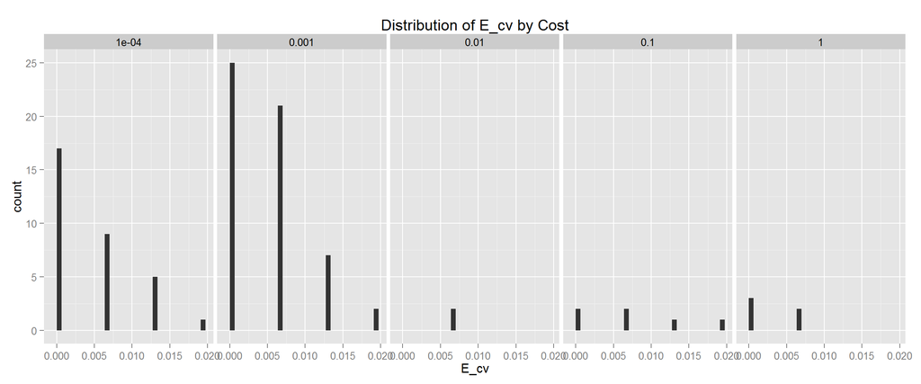

```r
m<-ggplot( grid_results, aes(x=E_out, xlab = "E_cv") ) +geom_histogram() + facet_grid( . ~ Cost) +
  xlab("E_cv") +ggtitle ("Distribution of E_cv by Cost")
print(m)
```

```r
library(foreach)
library(data.table)
require(caret)

REPS=10
Costs=10^(-4:0)
set.seed(1215)
set.seed(1539)
all.reps=foreach (r=c(1:REPS), .combine = rbind) %do% {
  fldIdx = with(trn15, createFolds(y, 10, list=F))
  cvRes = foreach(fld=c(1:10), .combine = rbind) %do% {
    cRes = foreach (cs=10^(-4:0), combine = rbind) %do% {
      smod = getSvm(trn15[fldIdx!=fld,], Cost = cs)
      stat = svm.stats ( smod, trn15[fldIdx!=fld,], trn15[fldIdx==fld,])
      c.res = cbind(stat, Cost=cs, REP=r)
    }
  }
  #cvRes[order(cvRes$E_out, cvRes$Cost),][1,]
}

resdt = data.table(all.reps)
resdt[,.N, by=Cost]
resdt[,mean(E_out), by=Cost]
```

[output not shown]

The code below uses svm cross validataion parameter to get winner in each run. Runs are manual.

```r
library(foreach)
library(data.table)
REPS=100
Costs=10^(-4:0)
set.seed(1215)
set.seed(1539)
all.reps=foreach (r=1:REPS, .combine = rbind) %do% {
  all.res = foreach(cc = Costs, .combine = rbind) %do% {
    sss = svm( y ~ symmetry + intensity,
           data=trn15,
           kernel= 'polynomial', degree= 2 , cost= cc, coef0=1, gamma=1,
           scale=F, cross = 10)
    data.frame( Cost = cc, E_out = 1 - sss$accuracies/100)
  }
  #topres= all.res[order(all.res$E_out, all.res$Cost),][1,]
}

grid_results = data.table(all.reps)

#this works if topres is uncommented
grid_results[,.N, by=Cost]
```

```
##     Cost    N
## 1: 1e-04 1000
## 2: 1e-03 1000
## 3: 1e-02 1000
## 4: 1e-01 1000
## 5: 1e+00 1000
```

```r
grid_results[,list(E_cv=mean(E_out)), by=Cost]
```

```
##     Cost     E_cv
## 1: 1e-04 0.009603
## 2: 1e-03 0.004483
## 3: 1e-02 0.004483
## 4: 1e-01 0.004483
## 5: 1e+00 0.005765
```

[output not shown]

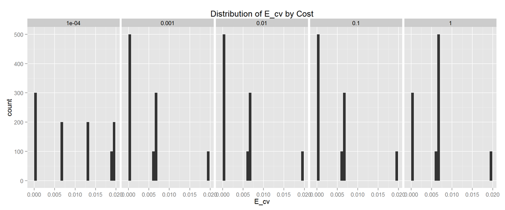

```r
m<-ggplot( grid_results, aes(x=E_out, xlab = "E_cv") ) +geom_histogram() +
  facet_grid( . ~ Cost) +
  xlab("E_cv") +ggtitle ("Distribution of E_cv by Cost")
print(m)
```

### Trying Tuning Methods from caret package

This is an attempt do do automatic model selection with parameters using Caret package.

Current issues is passing exact parameters to kernlab svm function, and hot having variables scaled. Also it apperas that caret mixes up Cost variable in passing it through the model.

Obeservations are made examining best.model manually.

```r
library(caret)
Costs = 10^(-4:0)

#lets sets seeds for reproducable resamples
set.seed(1027)
seeds = sample.int(1000, 100)

svmGrid = data.frame(degree = 2,
                     scale = F, #this is really a cost
                     C = Costs #scale
                     #type = "C-svc",
                     #kernel = "polydot",
                     #offset = 1
                     )

trainSettings = trainControl( method = "repeatedcv",
                              number=10, repeats=10,
                              seeds = seeds,
                              allowParallel=T)

svmCV <- train ( y ~ symmetry + intensity, data = trn15,
                 method = 'svmPoly',
                 tuneGrid = svmGrid,
                 preProcess  = NULL
                 )
```

#### Trying tuning methods from e0171 package

This is an attempt using automatic tuning paramters from e1071 package. Current issue is that it returns the same Errors for all cost values.

```r
library(e1071)

Costs = 10^(-4:0)

ctlObj = tune.control(sampling = "cross", cross=10, performances = T )

tunObj = tune(svm, y ~ intensity + symmetry, data = trn15,
              ranges = list(kernel= 'polynomial', degree = 2, costs = Costs,
                            coef0 = 1, gamma = 1, scale = F),
              tunecontrol = ctlObj)
tunObj$performances
```

```
##       kernel degree costs coef0 gamma scale    error dispersion
## 1 polynomial      2 1e-04     1     1 FALSE 0.003842   0.006191
## 2 polynomial      2 1e-03     1     1 FALSE 0.003842   0.006191
## 3 polynomial      2 1e-02     1     1 FALSE 0.003842   0.006191
## 4 polynomial      2 1e-01     1     1 FALSE 0.003842   0.006191
## 5 polynomial      2 1e+00     1     1 FALSE 0.003842   0.006191
```

```r
tunObj$best.parameters
```

```
##       kernel degree costs coef0 gamma scale
## 1 polynomial      2 1e-04     1     1 FALSE
```

```r
tunObj = tune(svm, y ~ intensity + symmetry, data = trn15,
              ranges = list(kernel= 'polynomial', degree = 2, costs = Costs,
                            coef0 = 1, gamma = 1, scale = F)
              #tunecontrol = ctlObj
              )
tunObj$performances
```

```
##       kernel degree costs coef0 gamma scale   error dispersion
## 1 polynomial      2 1e-04     1     1 FALSE 0.00512   0.005879
## 2 polynomial      2 1e-03     1     1 FALSE 0.00512   0.005879
## 3 polynomial      2 1e-02     1     1 FALSE 0.00512   0.005879
## 4 polynomial      2 1e-01     1     1 FALSE 0.00512   0.005879
## 5 polynomial      2 1e+00     1     1 FALSE 0.00512   0.005879
```

```r
tunObj$best.parameters
```

```
##       kernel degree costs coef0 gamma scale
## 1 polynomial      2 1e-04     1     1 FALSE
```

### RBF Kernel

Consider the radial basis function (RBF) kernel. Results are sensible and accepted.

```r
require(e1071)
require(foreach)
require(ggplot2)
require(gridExtra)
Costs=10^c(-2, 0, 2, 4, 6)

#sapply(Costs, function(x) { s = getRBF(trn15, Cost=x); s.s = svm.stats( s, trn15, tst15)})
foreach(x=Costs, .combine = rbind)   %do% {
    s = getRBF(trn15, Cost=x);
    s.s = svm.stats( s, trn15, tst15)
    cbind(s.s, Cost=x)
}
```

```
##   N_sv      E_in   E_out  Cost
## 1  406 0.0038437 0.02358 1e-02
## 2   32 0.0044843 0.02123 1e+00
## 3   22 0.0032031 0.01887 1e+02
## 4   19 0.0025625 0.02358 1e+04
## 5   17 0.0006406 0.02358 1e+06
```

The Plot below is for cost = 10e6

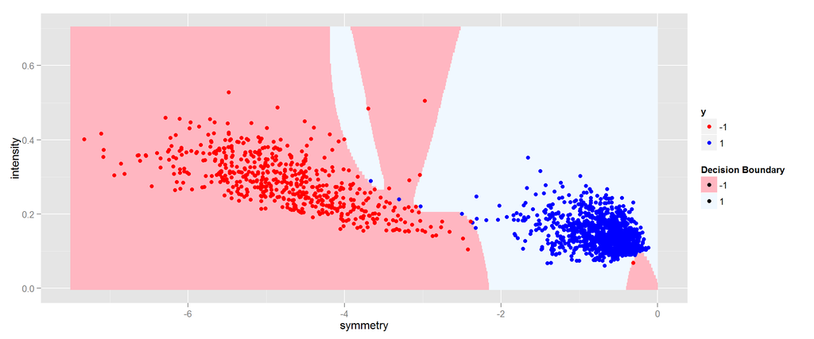

```r
s_p6 = getRBF(trn15, Cost=10^6)
p1=svm_plot(s_p6, trn15)
print(p1)
```

The plot Below is for cost=100

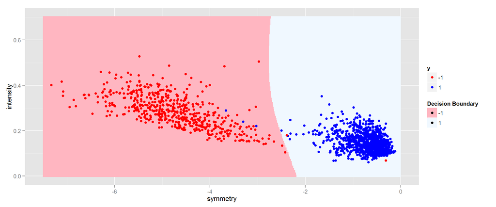

```r
s_p2 <- getRBF(trn15, Cost=10^2)
p2<-svm_plot(s_p2, trn15)
print(p2)
```

Code below still does not work even with environemtn trick. will need to define a real closure for this to work.

```r
require(gridExtra)
grid.arrange( p1, p2, ncol=2, main = textGrob("SVM DB with 10^6 and 10^2"))
```